# California Housing Prices Predictive Modeling

The development of a housing prices prediction model can assist a house seller or a real estate agent to make better-informed decisions based on house price valuation.

```python
import pandas as pd
import matplotlib.pyplot as plt
import seaborn as sns
```

## 1. Exploratory Data Analysis

```python
housing_data = pd.read_csv('datasets/housing.csv')
```

```python
housing_data.head()
```

|  | longitude | latitude | housing_median_age | total_rooms | total_bedrooms | population | households | median_income | median_house_value | ocean_proximity |
| --- | --- | --- | --- | --- | --- | --- | --- | --- | --- | --- |
| 0 | -122.23 | 37.88 | 41.0 | 880.0 | 129.0 | 322.0 | 126.0 | 8.3252 | 452600.0 | NEAR BAY |
| 1 | -122.22 | 37.86 | 21.0 | 7099.0 | 1106.0 | 2401.0 | 1138.0 | 8.3014 | 358500.0 | NEAR BAY |
| 2 | -122.24 | 37.85 | 52.0 | 1467.0 | 190.0 | 496.0 | 177.0 | 7.2574 | 352100.0 | NEAR BAY |
| 3 | -122.25 | 37.85 | 52.0 | 1274.0 | 235.0 | 558.0 | 219.0 | 5.6431 | 341300.0 | NEAR BAY |
| 4 | -122.25 | 37.85 | 52.0 | 1627.0 | 280.0 | 565.0 | 259.0 | 3.8462 | 342200.0 | NEAR BAY |

```python
housing_data.shape
```

```
(20640, 10)
```

```python
housing_data.describe()
```

|  | longitude | latitude | housing_median_age | total_rooms | total_bedrooms | population | households | median_income | median_house_value |
| --- | --- | --- | --- | --- | --- | --- | --- | --- | --- |
| count | 20640.000000 | 20640.000000 | 20640.000000 | 20640.000000 | 20433.000000 | 20640.000000 | 20640.000000 | 20640.000000 | 20640.000000 |
| mean | -119.569704 | 35.631861 | 28.639486 | 2635.763081 | 537.870553 | 1425.476744 | 499.539680 | 3.870671 | 206855.816909 |
| std | 2.003532 | 2.135952 | 12.585558 | 2181.615252 | 421.385070 | 1132.462122 | 382.329753 | 1.899822 | 115395.615874 |
| min | -124.350000 | 32.540000 | 1.000000 | 2.000000 | 1.000000 | 3.000000 | 1.000000 | 0.499900 | 14999.000000 |
| 25% | -121.800000 | 33.930000 | 18.000000 | 1447.750000 | 296.000000 | 787.000000 | 280.000000 | 2.563400 | 119600.000000 |
| 50% | -118.490000 | 34.260000 | 29.000000 | 2127.000000 | 435.000000 | 1166.000000 | 409.000000 | 3.534800 | 179700.000000 |
| 75% | -118.010000 | 37.710000 | 37.000000 | 3148.000000 | 647.000000 | 1725.000000 | 605.000000 | 4.743250 | 264725.000000 |
| max | -114.310000 | 41.950000 | 52.000000 | 39320.000000 | 6445.000000 | 35682.000000 | 6082.000000 | 15.000100 | 500001.000000 |

Removing rows with missing values

```python
housing_data = housing_data.dropna()
```

```python
housing_data.shape
```

```
(20433, 10)
```

```python
housing_data['ocean_proximity'].unique()
```

```
array(['NEAR BAY', '<1H OCEAN', 'INLAND', 'NEAR OCEAN', 'ISLAND'],
      dtype=object)
```

```python
housing_data['ocean_proximity'].value_counts()
```

```
<1H OCEAN     9034
INLAND        6496
NEAR OCEAN    2628
NEAR BAY      2270
ISLAND           5
Name: ocean_proximity, dtype: int64
```

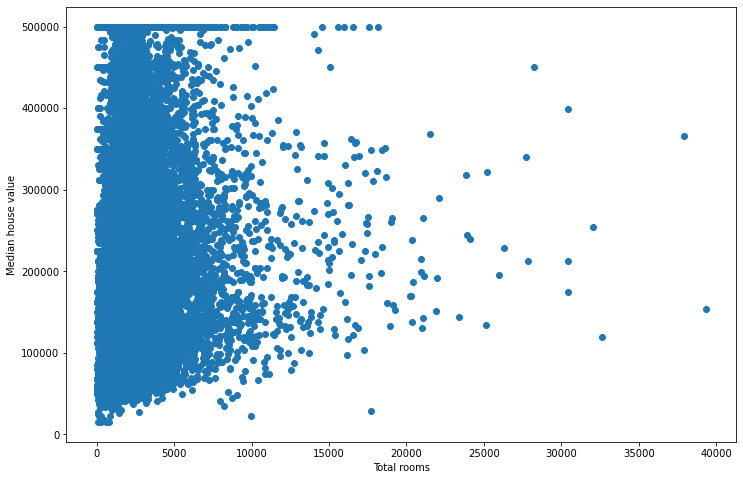

```python
fig, x = plt.subplots(figsize =(12,8))
plt.scatter(housing_data['total_rooms'], housing_data['median_house_value'])
plt.xlabel('Total rooms')
plt.ylabel('Median house value')
```

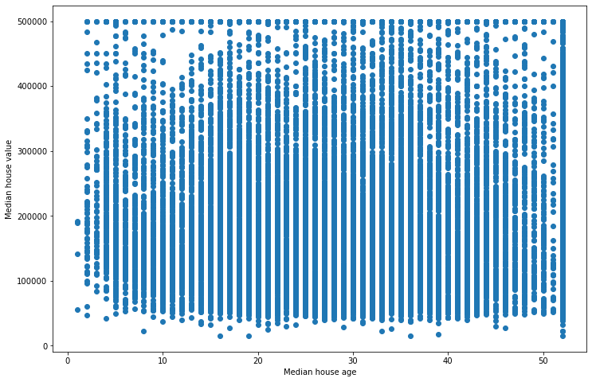

```python
fig, x = plt.subplots(figsize =(12,8))
plt.scatter(housing_data['housing_median_age'], housing_data['median_house_value'])
plt.xlabel('Median house age')
plt.ylabel('Median house value')
```

It's difficult to detect any pattern from this visualization. We could be expecting that new houses price should be higher. However maybe new buildings are not in the best locations

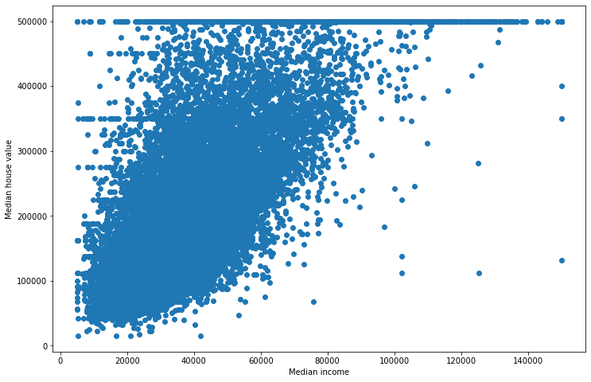

```python
fig, x = plt.subplots(figsize =(12,8))
plt.scatter(housing_data['median_income']*10000, housing_data['median_house_value'])
plt.xlabel('Median income')
plt.ylabel('Median house value')
```

The scatter plot has a clear upward flow, showing a clear positive elatinship between media income and house prices

Let's now inspect the correlation between variables

```python
housing_data_corr = housing_data.corr()
housing_data_corr
```

|  | longitude | latitude | housing_median_age | total_rooms | total_bedrooms | population | households | median_income | median_house_value |
| --- | --- | --- | --- | --- | --- | --- | --- | --- | --- |
| longitude | 1.000000 | -0.924616 | -0.109357 | 0.045480 | 0.069608 | 0.100270 | 0.056513 | -0.015550 | -0.045398 |
| latitude | -0.924616 | 1.000000 | 0.011899 | -0.036667 | -0.066983 | -0.108997 | -0.071774 | -0.079626 | -0.144638 |
| housing_median_age | -0.109357 | 0.011899 | 1.000000 | -0.360628 | -0.320451 | -0.295787 | -0.302768 | -0.118278 | 0.106432 |
| total_rooms | 0.045480 | -0.036667 | -0.360628 | 1.000000 | 0.930380 | 0.857281 | 0.918992 | 0.197882 | 0.133294 |
| total_bedrooms | 0.069608 | -0.066983 | -0.320451 | 0.930380 | 1.000000 | 0.877747 | 0.979728 | -0.007723 | 0.049686 |
| population | 0.100270 | -0.108997 | -0.295787 | 0.857281 | 0.877747 | 1.000000 | 0.907186 | 0.005087 | -0.025300 |
| households | 0.056513 | -0.071774 | -0.302768 | 0.918992 | 0.979728 | 0.907186 | 1.000000 | 0.013434 | 0.064894 |
| median_income | -0.015550 | -0.079626 | -0.118278 | 0.197882 | -0.007723 | 0.005087 | 0.013434 | 1.000000 | 0.688355 |
| median_house_value | -0.045398 | -0.144638 | 0.106432 | 0.133294 | 0.049686 | -0.025300 | 0.064894 | 0.688355 | 1.000000 |

Let's better visualize thoses correlation using a heatmap

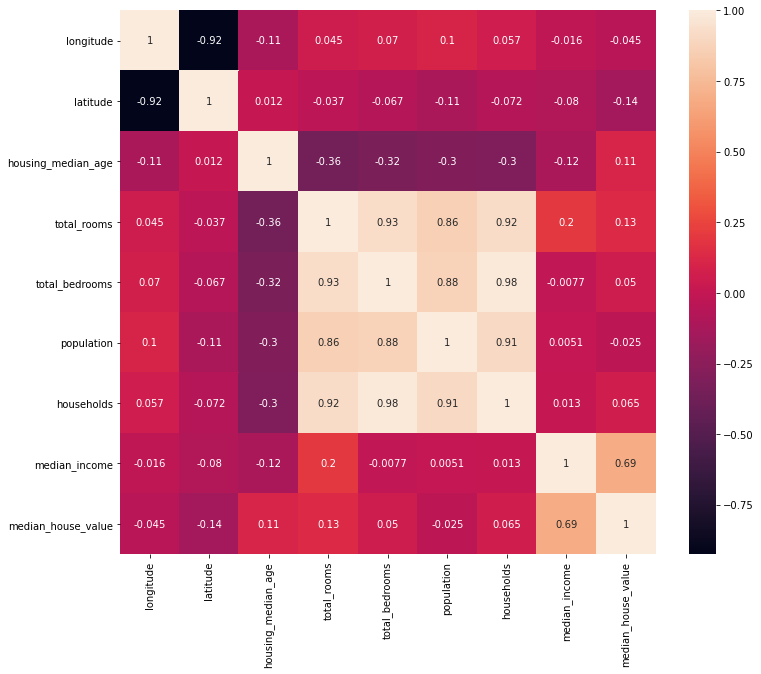

```python
fig, x = plt.subplots(figsize =(12,10))
sns.heatmap(housing_data_corr, annot=True);
```

## 2. Building a Linear Regresion Machine Learning Model to predict house price

When we have explored our dataset we had seen a number of points clustered around the housing price $500.000

We had also noticed that the maximum value associated with a particular house was is $500.001

Let's check how many houses in the dataset have a median value of $500.001

```python
housing_data.sample(3)
```

|  | longitude | latitude | housing_median_age | total_rooms | total_bedrooms | population | households | median_income | median_house_value | ocean_proximity |
| --- | --- | --- | --- | --- | --- | --- | --- | --- | --- | --- |
| 15078 | -116.97 | 32.83 | 23.0 | 149.0 | 32.0 | 101.0 | 34.0 | 2.6458 | 112500.0 | <1H OCEAN |
| 12987 | -121.27 | 38.70 | 16.0 | 3747.0 | 586.0 | 1817.0 | 590.0 | 4.6488 | 145300.0 | INLAND |
| 6967 | -118.04 | 33.98 | 50.0 | 1951.0 | 458.0 | 1362.0 | 454.0 | 3.0000 | 163200.0 | <1H OCEAN |

```python
housing_data.query("median_house_value == 500001").median_house_value.count()
```

```
958
```

Nearly 1000 records of our 20000 records dataset are at this price. This can really skew the training of our machine learning model

It is best to drop those records

```python
housing_data = housing_data.drop(housing_data.loc[housing_data["median_house_value"] == 500001].index)
```

```python
# Check
housing_data.loc[housing_data["median_house_value"] == 500001].median_house_value.count()
```

```
0
```

We should now convert the ocean_proximity column to a numercial form. For that we are going to generate dummy variables

```python
housing_data = pd.get_dummies(housing_data, columns = ['ocean_proximity'])
```

```python
housing_data.columns
```

```
Index(['longitude', 'latitude', 'housing_median_age', 'total_rooms',
       'total_bedrooms', 'population', 'households', 'median_income',
       'median_house_value', 'ocean_proximity_<1H OCEAN',
       'ocean_proximity_INLAND', 'ocean_proximity_ISLAND',
       'ocean_proximity_NEAR BAY', 'ocean_proximity_NEAR OCEAN'],
      dtype='object')
```

We have now 5 new columns in our dataset, each column correspond to a dummy variable

'ocean*proximity*<1H OCEAN'  
'ocean_proximity_INLAND'  
'ocean_proximity_ISLAND'  
'ocean_proximity_NEAR BAY'  
'ocean_proximity_NEAR OCEAN'

It is time now to set up features and target for our model  
X values are features or data used to train our machine learning model, and Y values are predictions

```python
#X correspond to all our dataframe except the target column (median_house_value)
X = housing_data.drop("median_house_value", axis = 1)
```

```python
X.columns
```

```
Index(['longitude', 'latitude', 'housing_median_age', 'total_rooms',
       'total_bedrooms', 'population', 'households', 'median_income',
       'ocean_proximity_<1H OCEAN', 'ocean_proximity_INLAND',
       'ocean_proximity_ISLAND', 'ocean_proximity_NEAR BAY',
       'ocean_proximity_NEAR OCEAN'],
      dtype='object')
```

```python
# Y correspond the the target of our model
Y = housing_data["median_house_value"]
```

We should split our data into a trainning set and a test set

```python
# Splitting our data 20/80 and shuffling records using train_test_split

from sklearn.model_selection import train_test_split
x_train, x_test, y_train, y_test = train_test_split(X, Y, test_size=0.2)
```

```python
x_train.shape, x_test.shape
```

```
((15580, 13), (3895, 13))
```

```python
y_train.shape, y_test.shape
```

```
((15580,), (3895,))
```

We will use linear regression estimator object to perform our ML regression modeling

```python
from sklearn.linear_model import LinearRegression

# normalazing observations (all values become between 0 and 1)
# fitting a linear regression model
linear_model = LinearRegression(normalize=True).fit(x_train,y_train)
```

After the model has trained let's evaluate its score using R². In other words this value helps us to estimate how well our linear model captures the underlying variation in our training data

```python
print("model score:" , linear_model.score(x_train, y_train))
```

```
model score: 0.6155589197578579
```

- The linear model captured 60% of variation in our training data

Let's know take a look at the coefficients of our linear model associated with each feature

```python
predictors = x_train.columns
predictors
```

```
Index(['longitude', 'latitude', 'housing_median_age', 'total_rooms',
       'total_bedrooms', 'population', 'households', 'median_income',
       'ocean_proximity_<1H OCEAN', 'ocean_proximity_INLAND',
       'ocean_proximity_ISLAND', 'ocean_proximity_NEAR BAY',
       'ocean_proximity_NEAR OCEAN'],
      dtype='object')
```

```python
coef = pd.Series(linear_model.coef_, predictors).sort_values()
print(coef)
```

```
ocean_proximity_INLAND        -25501.404584
longitude                     -24471.621148
latitude                      -22649.498948
population                       -31.399028
total_rooms                       -7.173280
households                        52.508385
total_bedrooms                    85.930852
housing_median_age               930.344770
ocean_proximity_NEAR BAY        7064.737761
ocean_proximity_<1H OCEAN      12658.230638
ocean_proximity_NEAR OCEAN     16980.410243
median_income                  38676.306560
ocean_proximity_ISLAND        195613.548784
dtype: float64
```

- Each coefficient give an idea about how much that particular feature contributed toward the prediction.
- Negative coefficients are associated with features that tend to lower the price
- Positive coefficients are associated with features that tend to increase the price

Now we have trained our model let's use it to predict

```python
y_pred = linear_model.predict(x_test)
```

How our model perform ?  
Let's create a dataframe that compares our predicted values with actual values that we have in our dataset

```python
df_pred_actual = pd.DataFrame({'predicted' : y_pred, "actual" : y_test})
```

```python
df_pred_actual.head()
```

|  | predicted | actual |
| --- | --- | --- |
| 3038 | 143171.036290 | 82800.0 |
| 19095 | 260700.069909 | 188500.0 |
| 4733 | 230767.934828 | 338100.0 |
| 3463 | 227754.658857 | 173100.0 |
| 16228 | 112621.376617 | 92600.0 |

```python
from sklearn.metrics import r2_score
print("testing score:", r2_score(y_test, y_pred))
```

```
testing score: 0.6019226812096348
```

R² is almost good as it was in the training instances. Our model perform as well on instances it has not seen before as on the training data

Now let's create a sample and ploat "actual" versus "predicted" values using a line chart to get a visual idea on how our model perform

```python
df_pred_actual = df_pred_actual.sample(100)
df_pred_actual = df_pred_actual.reset_index()
```

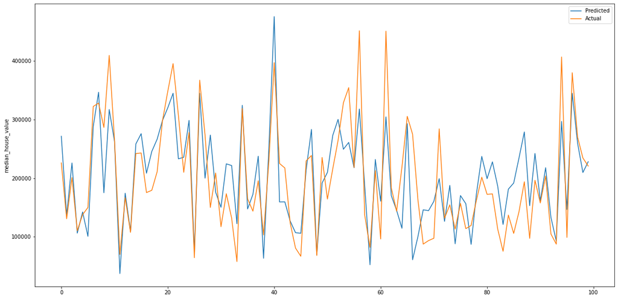

```python
plt.figure(figsize = (20,10))

plt.plot(df_pred_actual['predicted'] , label="Predicted")
plt.plot(df_pred_actual['actual'] , label="Actual")

plt.ylabel('median_house_value')

plt.legend()
plt.show()
```

## 3. Building a Logistic Regresion Machine Learning Classifier to classify house prices

The aim is to classify house prices as above the median price or below the median price.  
First let's calculate the median house price

```python
housing_data.sample()
```

|  | longitude | latitude | housing_median_age | total_rooms | total_bedrooms | population | households | median_income | median_house_value | ocean_proximity_<1H OCEAN | ocean_proximity_INLAND | ocean_proximity_ISLAND | ocean_proximity_NEAR BAY | ocean_proximity_NEAR OCEAN |
| --- | --- | --- | --- | --- | --- | --- | --- | --- | --- | --- | --- | --- | --- | --- |
| 16459 | -121.29 | 38.12 | 18.0 | 1534.0 | 275.0 | 741.0 | 263.0 | 3.9607 | 132500.0 | 0 | 1 | 0 | 0 | 0 |

```python
median = housing_data['median_house_value'].median()
median
```

```
173800.0
```

After we have calculated the median variable let's now create a new column named "above_medium" which indicate weither the median house price for a giving observation is above the median price or not.

```python
housing_data['above_median'] = (housing_data['median_house_value'] - median) > 0
```

```python
housing_data.sample(5)
```

|  | longitude | latitude | housing_median_age | total_rooms | total_bedrooms | population | households | median_income | median_house_value | ocean_proximity_<1H OCEAN | ocean_proximity_INLAND | ocean_proximity_ISLAND | ocean_proximity_NEAR BAY | ocean_proximity_NEAR OCEAN | above_median |
| --- | --- | --- | --- | --- | --- | --- | --- | --- | --- | --- | --- | --- | --- | --- | --- |
| 9618 | -120.46 | 37.29 | 30.0 | 2972.0 | 635.0 | 1940.0 | 590.0 | 2.3594 | 72300.0 | 0 | 1 | 0 | 0 | 0 | False |
| 3493 | -118.48 | 34.28 | 35.0 | 1511.0 | 274.0 | 873.0 | 254.0 | 5.5608 | 226700.0 | 1 | 0 | 0 | 0 | 0 | True |
| 3359 | -120.64 | 40.41 | 50.0 | 1741.0 | 424.0 | 987.0 | 383.0 | 1.5066 | 59300.0 | 0 | 1 | 0 | 0 | 0 | False |
| 13627 | -117.27 | 34.10 | 9.0 | 3904.0 | 1042.0 | 3688.0 | 896.0 | 1.8022 | 78000.0 | 0 | 1 | 0 | 0 | 0 | False |
| 13773 | -116.98 | 34.05 | 6.0 | 2290.0 | 312.0 | 957.0 | 274.0 | 7.2708 | 316700.0 | 0 | 1 | 0 | 0 | 0 | True |

It is time now to set up features and target for our model  
X values are features or data used to train our machine learning model, and Y values are predictions

```python
#Xlog correspond to all our dataframe except the median_house_value and above_median columns
Xlog = housing_data.drop(['median_house_value' , 'above_median'] , axis = 1)
```

```python
Xlog.columns
```

```
Index(['longitude', 'latitude', 'housing_median_age', 'total_rooms',
       'total_bedrooms', 'population', 'households', 'median_income',
       'ocean_proximity_<1H OCEAN', 'ocean_proximity_INLAND',
       'ocean_proximity_ISLAND', 'ocean_proximity_NEAR BAY',
       'ocean_proximity_NEAR OCEAN'],
      dtype='object')
```

```python
#Ylog is our binary variable (true or false)
Ylog = housing_data['above_median']
```

We should split our data into a trainning set and a test set

```python
# Splitting our data 20/80 and shuffling records using train_test_split


from sklearn.model_selection import train_test_split
xlog_train, xlog_test, ylog_train, ylog_test = train_test_split(Xlog, Ylog, test_size = 0.2)
```

```python
xlog_train.shape, xlog_test.shape
```

```
((15580, 13), (3895, 13))
```

```python
ylog_train.shape , ylog_test.shape
```

```
((15580,), (3895,))
```

With our data all set up we are now ready to perform the logistic regression classification using the LogisticRegression object estimator from sklearn.linear_model

```python
# liblinear solver is a good choice when performing logistic regresion on a small dataset
from sklearn.linear_model import LogisticRegression
logistic_model = LogisticRegression(solver = 'liblinear').fit(xlog_train, ylog_train)
```

After the model has trained let's evaluate it performance

```python
print('Training score is :' , logistic_model.score(xlog_train, ylog_train))
```

```
Training score is : 0.8181001283697048
```

82% of the predictions were correct on our training data.  
But how does it perform on our test data ?

```python
ylog_pred = logistic_model.predict(xlog_test)
```

Let's create a new dataframe with predicted versus actual values

```python
dflog_pred_actual = pd.DataFrame({'predicted' : ylog_pred , 'actual' : ylog_test })
```

```python
dflog_pred_actual.sample(10)
```

|  | predicted | actual |
| --- | --- | --- |
| 9797 | True | True |
| 19077 | True | True |
| 10692 | True | False |
| 1317 | False | True |
| 1560 | True | True |
| 4392 | False | False |
| 12681 | False | False |
| 9458 | False | False |
| 8516 | True | True |
| 10654 | True | True |

Let's now calculate the accuracy of our model on test data

```python
from sklearn.metrics import accuracy_score
print('Testing score :', accuracy_score(ylog_test, ylog_pred))
```

```
Testing score : 0.8295250320924262
```

82.9 % of our model predictions were correct